# Denmark Statistics and large health data: We don’t know what we’re doing

Luke W. Johnston

September 25, 2025

# Who am I? 👋 👋

## History

- MSc and PhD in Nutritional Science in Toronto, Canada
- (Previous) Research in diabetes epidemiology
- Team leader at SDCA for the [Seedcase Project](https://seedcase-project.org), an NNF funded software project to simplify building FAIR data

## My work on large data

- [ukbAid](https://steno-aarhus.github.io/ukbAid/): R package and website
- [DARTER Project](https://steno-aarhus.github.io/darter-project/): Website of application to and documentation on a DST project

# Rationale for this talk

Aside from being asked to present on it 🤪

## We are woefully behind on data engineering and programming practices

Especially when working with massive data

## This impacts how we do effective and accurate research

## This is important because:

- Validity of results
- Speed impacts time to results
- Ability to do more complex analysis with more data
- Resources (which cost money)

# Aim of this talk

1. Highlight issues with Denmark Statistics and the research using the registers (and any other large data)
2. Spread awareness of how critical programming skills are, especially for large data
3. Showcase a few tools for doing research faster, so you can focus on doing science

## General “roadmap” 🗺️

- Issues with DST
- Need for dedicated programming expertise
- Questionable reproducibility and validity

# Denmark Statistics, the good *and* the bad

Anyone do research with DST?

## The good: Amazing resource, gold mine of data

*Nearly* unique in the world!

## And the bad…

For this talk, only basic things

## Everyone works on same server

- No queue system for analyses
- Can crash your analysis if others use more memory

*Waste of resources, slows research*

## Everyone works in same folder in a project

```
project/
├── luke/
│   └── analysis/
└── omar/
    └── paper/
```

Collaboration is difficult:

- *Anyone* can edit anything
- Can’t know who changed what and when (no “version control”)
- Not easy to review and improve other’s code

Slows research down

## Data is stored in a proprietary SAS format

For example, BEF register:

```
bef2018.sas7bdat
bef2019.sas7bdat
bef2020.sas7bdat
bef2021.sas7bdat
bef2022.sas7bdat
```

Takes many minutes to load one year of data (in R)

*Waste of time and resources*

## Data updates make more work for us

```
bef2021.sas7bdat
bef2022.sas7bdat
December_2023/bef2022.sas7bdat
December_2023/bef2023.sas7bdat
```

**Can you see the issue?**

*Again, waste of time*

## Metadata is confusing and poorly documented

- Variables are not consistent across years
- Finding the metadata is difficult

*Slows research down, wastes time*

## DST is either unaware of or indifferent to improving things

## Highlights lack of engineering and design expertise at DST

- Puts tech burden onto researchers

# Need programming expertise, especially for large data

An organization should be responsible for having a well-designed setup, otherwise, its on the researcher. But that’s not their expertise.

## Two tools as examples: Parquet and DuckDB

https://parquet.apache.org/

https://duckdb.org/

## Parquet should be used to store large data

Most data formats are row-based, like CSV or SAS. Newer formats tend to be column-based like Parquet.

### Row-based

```
name,sex,age
Tim,M,30
Jenny,F,25
```

### Column-based

```
name,Tim,Jenny
sex,M,F
age,30,25
```

## Column-based storage has many advantages

### Compression

```
name,Tim,Sam,Jenny
sex,M,F,F
age,30,30,25
```

…becomes…

[output not shown]

### Loading

- Computers read by lines
- Per line = same data type
- Only read needed columns

```
sex,M,F
age,30,25
```

## Parquet is 50-75% smaller than other formats

File size between CSV, Parquet, Stata, and SAS for `bef` register for 2017.

| File type | Size (MB) |
| --- | --- |
| SAS (`.sas7bdat`) | 1.45 Gb |
| CSV (`.csv`) | ~90% of SAS |
| Stata (`.dta`) | 745 Mb |
| Parquet (`.parquet`) | 398 Mb |

## Can partition data by a value (e.g. year) and load all at once

```
bef/year=2018/part-0.parquet
bef/year=2019/part-0.parquet
bef/year=2020/part-0.parquet
bef/year=2021/part-0.parquet
bef/year=2022/part-0.parquet
```

Load in R with `arrow` package:

```r
bef <- arrow::open_dataset("bef")
```

> Load all years in < 1 sec, compared to ~5 min for one year from SAS format

## DuckDB is a recent SQL engine designed for analytical queries

https://duckdb.org/

## SQL, or Structured Query Language, is a language for managing and querying databases

## DuckDB is impressively fast

- Faster than almost all other tools
  - Relatively complex queries (joins, group by, aggregates) on 55 Gb takes < 7.5 min <sup>1</sup>
  - Generally, simpler queries take < 10 seconds for massive datasets
- Easily connects with Parquet datasets
[^1]: From benchmark [page](https://duckdblabs.github.io/db-benchmark/).

## Example in DST

1. Load all 45 years of BEF
2. Drop all missing PNR
3. Group by year
4. Count sex

**Takes < 6 seconds**

## So… why is this important? Seems like easy stuff!

- Because it highlights a lack of expertise and understanding of some basic things

# Reproducibility and verification of research

Reproducibility: same data + same code = same results?

## Non-reproducibility is a *big*, though mostly unknown, issue

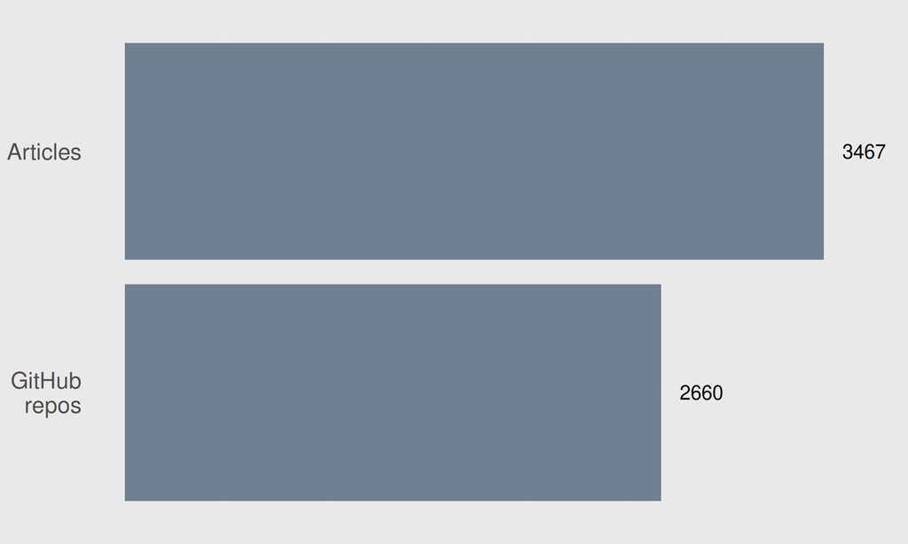

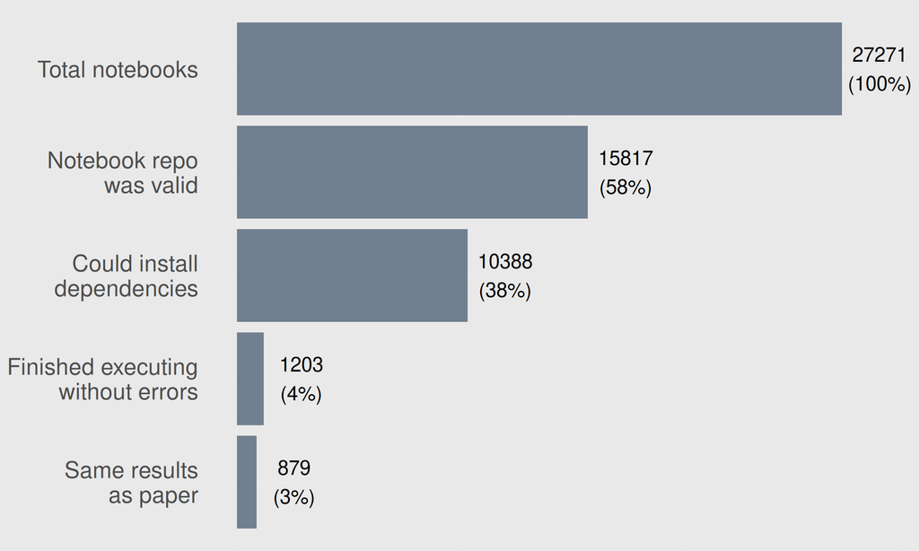

[DOI: 10.1093/gigascience/giad113](https://academic.oup.com/gigascience/article/doi/10.1093/gigascience/giad113/7516267?login=false)

## Analyzing, and reproducing, large data requires programming skills

- With massive data, you really need to know how to code and programming
- But, researchers are not trained for this kind of skill

## No one reviews code, so, no one knows if it’s correct

- This problem is bigger than people realize.

Or rather, *very* few formally review code.

## “Science as amateur software development”

> “But the code runs!”

From this academic [presentation](https://www.youtube.com/watch?v=8qzVV7eEiaI).

## Working in DST makes reproducibility harder

- Hard to review code
- Hard to collaborate
- No version control
- Use proprietary data formats
- No queue system
- No training materials or courses

## Science is not about trust, it’s about verification

Some trust is needed, but shouldn’t be dependent on it.

## It’s difficult to trust what researchers do in DST

# What to do?

## If reviewing papers, request or demand code is accessible

You don’t have to review it, just ask for it.

## Recognize, value, and reward those with programming expertise

## Pressure DST to improve things